# Raport

# MODEL

## Model wyjaśniający cenę miesięcznego wynajmu mieszkania

Te zmienne zostały wybrane, ponieważ są powszechnie uznawane za istotne czynniki wpływające na wartość nieruchomości na rynku wynajmu. Analiza ma na celu zrozumienie, jak każdy z tych czynników wpływa na cenę wynajmu oraz które z nich mają największe znaczenie dla potencjalnych najemców.

```
##
## Call:
## lm(formula = log(price) ~ avg_price + type + squareMeters + rooms +
##     buildYear + centreDistance + poiCount + schoolDistance +
##     hasElevator, data = Imputed_Data_Combined)
##
## Residuals:
##     Min      1Q  Median      3Q     Max
## -1.5701 -0.1351 -0.0001  0.1356  0.7970
##
## Coefficients:
##                    Estimate Std. Error t value Pr(>|t|)
## (Intercept)       3.791e+00  1.827e-01  20.751  < 2e-16 ***
## avg_price         2.012e-04  2.408e-06  83.549  < 2e-16 ***
## typeblockOfFlats -1.067e-01  5.309e-03 -20.097  < 2e-16 ***
## typetenement     -4.829e-02  8.494e-03  -5.686 1.34e-08 ***
## squareMeters      1.169e-02  2.048e-04  57.070  < 2e-16 ***
## rooms             5.201e-02  5.199e-03  10.004  < 2e-16 ***
## buildYear         1.439e-03  9.076e-05  15.851  < 2e-16 ***
## centreDistance   -2.765e-02  1.181e-03 -23.406  < 2e-16 ***
## poiCount          9.776e-04  1.052e-04   9.291  < 2e-16 ***
## schoolDistance    5.522e-02  7.701e-03   7.171 8.04e-13 ***
## hasElevatoryes    4.936e-02  5.426e-03   9.097  < 2e-16 ***
## ---
## Signif. codes:  0 '***' 0.001 '**' 0.01 '*' 0.05 '.' 0.1 ' ' 1
##
## Residual standard error: 0.2164 on 8838 degrees of freedom
## Multiple R-squared:  0.8008, Adjusted R-squared:  0.8005
## F-statistic:  3552 on 10 and 8838 DF,  p-value: < 2.2e-16
```

Wyniki modelu regresji liniowej pokazują, że zmienna zależna, logarytm ceny nieruchomości, jest wyjaśniana przez szereg istotnych statystycznie zmiennych niezależnych. Model ma bardzo dobre dopasowanie do danych, o czym świadczy wysoki współczynnik determinacji (R-squared = 0.8008), co oznacza, że około 80% zmienności logarytmu ceny nieruchomości jest wyjaśniane przez uwzględnione w modelu zmienne. Test F-statystyki (F-statistic = 3552, p < 2.2e-16) wskazuje, że model jako całość jest statystycznie istotny.

Reszty modelu są symetrycznie rozłożone wokół zera (mediana bliska 0), ale występują niewielkie odstępstwa na krańcach (wartości skrajne od -1.5701 do 0.7970). Błąd standardowy reszt (Residual standard error = 0.2164) wskazuje, że średni błąd przewidywania logarytmu ceny wynosi 0.2164.

Należy jednak pamiętać, że współczynniki w modelu są zlogarytmowane, co utrudnia ich bezpośrednią interpretację. Aby ułatwić interpretację, należy je przekształcić za pomocą funkcji wykładniczej, co pozwoli wyrazić je jako procentową zmianę ceny nieruchomości.

```
##      (Intercept)        avg_price typeblockOfFlats     typetenement
##    43.3056578426     0.0002011716    -0.1011958989    -0.0471456656
##     squareMeters            rooms        buildYear   centreDistance
##     0.0117547330     0.0533841156     0.0014396547    -0.0272741394
##         poiCount   schoolDistance   hasElevatoryes
##     0.0009780711     0.0567753015     0.0506034882
```

Wyniki przekształconych współczynników modelu regresji liniowej, uzyskane za pomocą funkcji wykładniczej (exp(coef(model_2)) - 1), pozwalają na bardziej intuicyjną interpretację wpływu poszczególnych zmiennych na cenę nieruchomości.

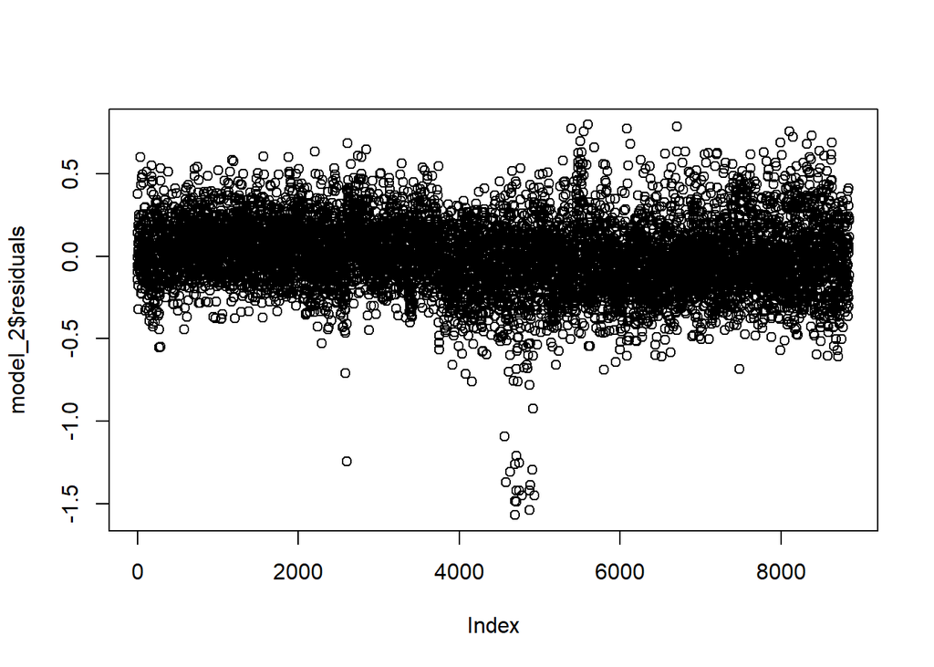

Analiza reszt modelu regresyjnego dostarcza istotnych informacji na temat jego jakości i zgodności z założeniami. Wykres przedstawiający reszty względem indeksu obserwacji pokazuje, że większość wartości rozkłada się wokół zera, co sugeruje brak silnych trendów. Niemniej jednak, zauważalne są pewne wartości odstające, szczególnie w dolnej części wykresu. Brak wyraźnego wzorca w resztach sugeruje, że założenie homoscedastyczności może być spełnione, ale wymaga to dodatkowej weryfikacji testem statystycznym.

```
##                    GVIF Df GVIF^(1/(2*Df))
## avg_price      1.478601  1        1.215977
## type           1.606535  2        1.125829
## squareMeters   4.014505  1        2.003623
## rooms          3.836129  1        1.958604
## buildYear      1.536221  1        1.239444
## centreDistance 1.815797  1        1.347515
## poiCount       1.606694  1        1.267554
## schoolDistance 1.244757  1        1.115687
## hasElevator    1.222044  1        1.105461
```

Analiza współczynników inflacji wariancji (VIF) wskazuje, że nie występuje istotny problem współliniowości pomiędzy zmiennymi niezależnymi. Wszystkie wartości VIF są poniżej progu krytycznego (5), co oznacza, że zmienne nie są nadmiernie skorelowane. Najwyższe wartości uzyskano dla zmiennych “squareMeters” (4.014) oraz “rooms” (3.836), co sugeruje pewną współliniowość, ale nie na poziomie wymagającym natychmiastowej interwencji.

```
##
##  studentized Breusch-Pagan test
##
## data:  model_2
## BP = 133.81, df = 10, p-value < 2.2e-16
```

Wynik testu Breuscha-Pagana, który sprawdza homoscedastyczność reszt, wskazuje na istotny problem z niejednorodnością wariancji. Bardzo niska wartość p (< 2.2e-16) sugeruje, że wariancja reszt nie jest stała, co może negatywnie wpływać na jakość oszacowań parametrów modelu.

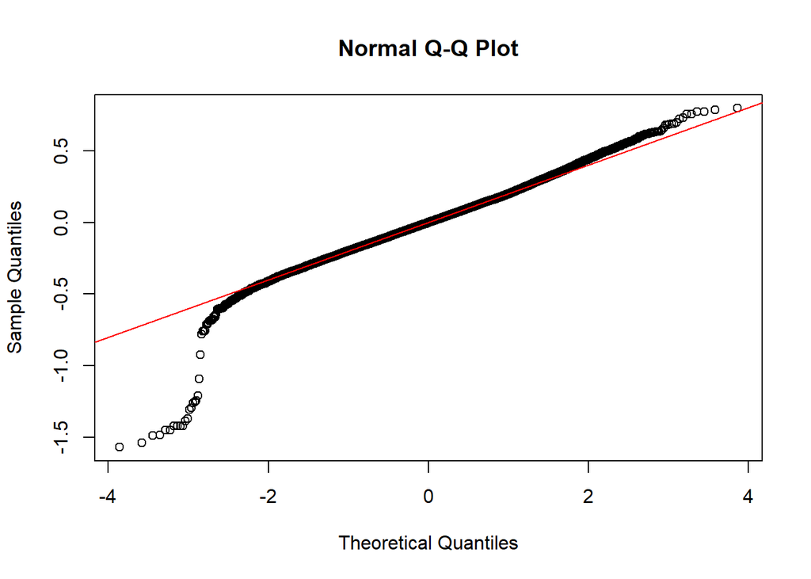

Wykres kwantyl-kwantyl (Q-Q plot) pozwala ocenić normalność rozkładu reszt. Idealnie dopasowane reszty powinny układać się wzdłuż czerwonej linii, co oznaczałoby zgodność z rozkładem normalnym. W tym przypadku widoczne są pewne odchylenia, szczególnie na krańcach wykresu, gdzie wartości odstające powodują rozproszenie punktów. Może to sugerować istnienie skośności w rozkładzie reszt, co może wpłynąć na interpretację wyników modelu oraz testów statystycznych. W przypadku tego modelu może to sugerować, że część danych dotyczyła wynajmu pokojów, co wpłynęło na występowanie bardzo niskich wartości. Analogicznie w zbiorze danych występują także bardzo drogie mieszkania na wynajem na cenę których może wpływać ich status „premium”.

Podsumowując, model wykazuje pewne nieprawidłowości, takie jak heteroskedastyczność oraz lekkie odchylenie reszt od normalności, co może wpływać na jego trafność. Jednak nasz model ma na celu poglądowe wytłumaczenie ceny wynajmu mieszkań.

# TESTY

## Test normalności rozkładu

W celu dokonania testu normalności rozkładu dla zmiennych ilościowych, z badanych danych, zastosujemy test normalności rozkładu Andersona-Darlinga. Test ten został wybrany ze względu na jego wysoką czułość w wykrywaniu odchyleń od normalności, szczególnie w przypadku dużych prób.

**Hipoteza zerowa (H₀)**: Dane posiadają rozkład normalny.

**Hipoteza alternatywna (H₁)**: Dane nie posiadają rozkładu normalnego.

```
##         squareMeters                rooms                floor
##              3.7e-24              3.7e-24              3.7e-24
##           floorCount            buildYear             latitude
##              3.7e-24              3.7e-24              3.7e-24
##            longitude       centreDistance             poiCount
##              3.7e-24              3.7e-24              3.7e-24
##       schoolDistance       clinicDistance   postOfficeDistance
##              3.7e-24              3.7e-24              3.7e-24
## kindergartenDistance   restaurantDistance      collegeDistance
##              3.7e-24              3.7e-24              3.7e-24
##     pharmacyDistance                price            avg_price
##              3.7e-24              3.7e-24              3.7e-24
```

Dla wszystkich analizowanych zmiennych numerycznych otrzymaliśmy bardzo niskie wartości, znacznie poniżej przyjętego poziomu istotności α = 0.05. Należy Odrzucić hipotezę zerową, na rzecz hipotezy alternatywnej - Dane nie posiadają rozkładu normalnego, więc do dalszej analizy wybieramy test Kruskala-Wallisa dla zmiennej ‘price’ względem ‘type’.

**Hipoteza zerowa (H₀)**: Mediany cen nieruchomości w różnych typach budynków są takie same.

**Hipoteza alternatywna (H₁)**: Istnieją istotne statystycznie różnice w medianie cen nieruchomości w zależności od typu budynku.

## Test Kruskala-Wallisa dla zmiennej ‘price’ względem ‘type’

## Wizualizacja testu Kruskala-Wallisa

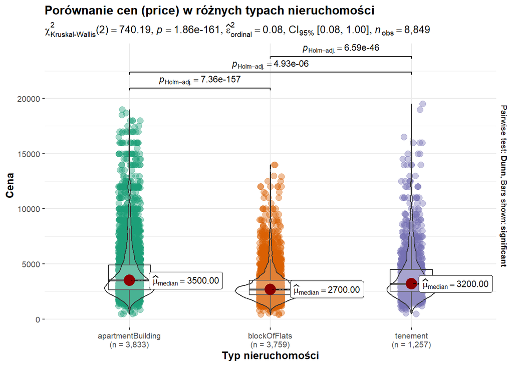

Na podstawie przeprowadzonego testu Kruskala-Wallisa dla zmiennej price względem zmiennej type uzyskano wynik, w którym statystyka chi-kwadrat wynosi 740.19 przy 2 stopniach swobody, a wartość p jest ekstremalnie niska (p = 1.86e−161). Takie wartość p wskazuje na podstawe do odrzucenia hipotezy zerowej, co oznacza, że istnieją istotne statystycznie różnice w medianach cen nieruchomości pomiędzy różnymi typami nieruchomości.

Wykres ilustruje te różnice, pokazując mediany cen dla trzech typów nieruchomości: apartmentBuilding (3500), blockOfFlats (2700) oraz tenement (3200). Widoczna jest wyraźna różnica w poziomie cen pomiędzy tymi kategoriami. Dodatkowo, przeprowadzone testy post-hoc Dunn’a z korektą Holm’a potwierdzają istotność różnic pomiędzy parami grup (p < 0.05 dla wszystkich porównań), co wskazuje, że każda z grup różni się istotnie od pozostałych pod względem mediany ceny.

Wyniki przeprowadzonego testu sugerują, że **typ nieruchomości ma istotny wpływ na poziom cen.** Najwyższe ceny obserwujemy w przypadku apartment buildings, podczas gdy block of flats cechują się najniższymi medianami cen. W związku z tym można stwierdzić, że rynek nieruchomości różnicuje ceny w zależności od typu budynku

## Test Chi-kwadrat dla zmiennej ‘condition’ względem ‘price’

W dalszej części zbadano czy istnieje, istotna statystycznie, zależność pomiędzy stanem technicznym nieruchomości (condition) a jej ceną (price). W tym celu wykorzystano test Chi-kwadrat, który pozwala ocenić, czy rozkład cen nieruchomości (podzielonych na kategorie: niskie, średnie, wysokie) jest zależny od stanu technicznego budynku. Analiza ta pozwoli określić, czy lepszy stan techniczny przekłada się na wyższe ceny, czy też nie ma istotnego wpływu. Dodatkowo wyniki zostaną zobrazowane na wykresie, co ułatwi interpretację zależności pomiędzy analizowanymi zmiennymi.

## Wizualizacja testu Chi-kwadrat

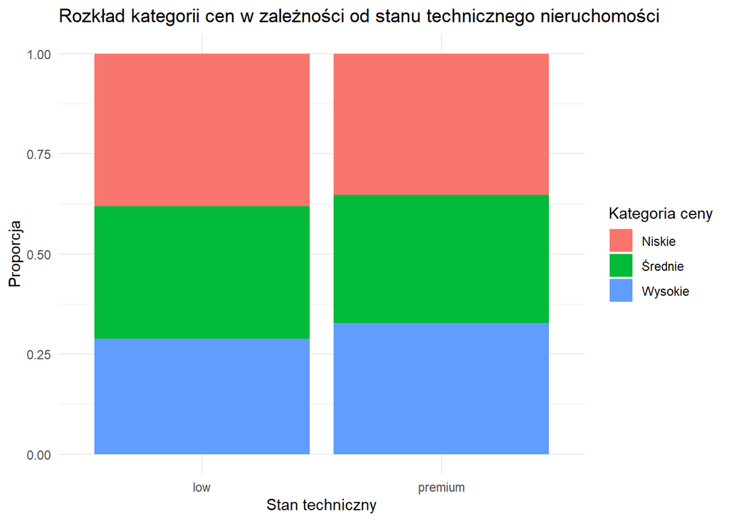

```
##
##  Pearson's Chi-squared test
##
## data:  table_chi
## X-squared = 0.8459, df = 2, p-value = 0.6551
```

Analiza wyników testu Chi-kwadrat pokazuje, że nie ma istotnej statystycznie zależności między stanem technicznym nieruchomości (low i premium) a jej kategorią cenową (Niskie, Średnie, Wysokie). Oznacza to, że stan techniczny nie wpływa znacząco na poziom cen – **nieruchomości w różnym stanie mogą znajdować się w podobnych przedziałach cenowych**.

# Podsumowanie analizy

W ramach projektu dokonano analizy zbioru danych, zawierającego informacje o wynajmie mieszkań w piętnastu największych miastach w Polsce (stan na czerwiec 2024). Celem badania było zidentyfikowanie kluczowych zależności między zmiennymi, a także określenie, które czynniki w największych stopniu determinują wysokość czynszu. Pierwszym etapem projektu było wstępne przetworzenie i eksploracja danych. Rozpoczęto od identyfikacji braków danych oraz wskazania wartości odstających. Kolejnym krokiem była walidacja danych, po której przystąpiono do zastosowania metod imputacji, aby zapewnić kompletność i spójność analizowanego zbioru. Zastosowanymi technikami imputacji były: algorytm MICE i metoda Hotdeck. Kolejny etap projektu obejmował wizualizację danych, mającą charakter czysto podglądowy. Następnie przystąpiono do analizy opisowej, aby lepiej zrozumieć badane dane oraz korelacje zachodzące między nimi. Przeprowadzono analizę korelacji między ceną najmu a innymi zmiennymi, w tym liczbą pokoi, rokiem budowy, odległością od centrum oraz bliskością placówek edukacyjnych.

W celu pogłębienia analizy zbudowano model regresji liniowej, w którym zmienną zależną była cena najmu, a zmiennymi niezależnymi kluczowe czynniki, takie jak średnia cena w mieście, typ budynku, metraż, liczba pokoi, rok budowy, odległość od centrum, liczba punktów zainteresowania w okolicy, odległość do szkoły oraz obecność windy. Model wykazał bardzo dobre dopasowanie do danych, a wszystkie zmienne były statystycznie istotne. Miał on jednak problem z heteroskedastycznością oraz rozkładem reszt, dlatego jest tylko modelem poglądowym.

W ramach dalszych analiz sprawdzono normalność rozkładu danych oraz przeprowadzono testy statystyczne.

Otrzymane wyniki mogą stanowić solidną podstawę do dalszych badań oraz wspierać proces podejmowania decyzji na rynku nieruchomości, zarówno od strony wynajmującego, jak i najemcy.